# ch01_01_ML_start_v13_2601

### 06. 데이터 살펴보기 - 시각화

- 머신러닝 모델을 만들기 전 머신러닝 없이도 풀 수 있는 문제는 아닌지, 혹은 필요한 정보가 누락이 없는지 확인
- 산점도(SCATTER PLOT)를 이용하여 확인.
  - 한특성을 x축에 놓고 다른 하나는 y축에 놓아 데이터를 점으로 나타내는 그래프
- 2개의 변수만 사용 가능하여 산점도 행렬(scatter matrix)를 사용

```python
import seaborn as sns
```

```python
iris.info()
```

```
<class 'pandas.core.frame.DataFrame'>
RangeIndex: 150 entries, 0 to 149
Data columns (total 5 columns):
 #   Column             Non-Null Count  Dtype
---  ------             --------------  -----
 0   sepal length (cm)  150 non-null    float64
 1   sepal width (cm)   150 non-null    float64
 2   petal length (cm)  150 non-null    float64
 3   petal width (cm)   150 non-null    float64
 4   target             150 non-null    int64
dtypes: float64(4), int64(1)
memory usage: 6.0 KB
```

```python
iris['target'] = iris['target'].astype('category') # 자료형 변환
iris.head()
```

|  | sepal length (cm) | sepal width (cm) | petal length (cm) | petal width (cm) | target |
| --- | --- | --- | --- | --- | --- |
| 0 | 5.1 | 3.5 | 1.4 | 0.2 | 0 |
| 1 | 4.9 | 3.0 | 1.4 | 0.2 | 0 |
| 2 | 4.7 | 3.2 | 1.3 | 0.2 | 0 |
| 3 | 4.6 | 3.1 | 1.5 | 0.2 | 0 |
| 4 | 5.0 | 3.6 | 1.4 | 0.2 | 0 |

```python
print(iris.shape)
print(iris.info())
```

```
(150, 5)
<class 'pandas.core.frame.DataFrame'>
RangeIndex: 150 entries, 0 to 149
Data columns (total 5 columns):
 #   Column             Non-Null Count  Dtype
---  ------             --------------  -----
 0   sepal length (cm)  150 non-null    float64
 1   sepal width (cm)   150 non-null    float64
 2   petal length (cm)  150 non-null    float64
 3   petal width (cm)   150 non-null    float64
 4   target             150 non-null    category
dtypes: category(1), float64(4)
memory usage: 5.1 KB
None
```

### seaborn를 활용한 산점도 행렬 확인

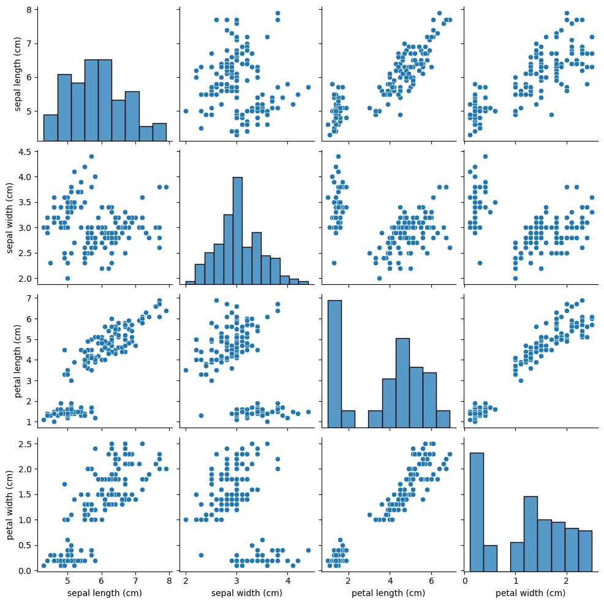

```python
sns.pairplot(iris.iloc[ : ,0:4])   # 1~4열 선택
```

### Pandas를 이용한 산점도 행렬 확인

```
array([[<Axes: xlabel='sepal length (cm)', ylabel='sepal length (cm)'>,
        <Axes: xlabel='sepal width (cm)', ylabel='sepal length (cm)'>,
        <Axes: xlabel='petal length (cm)', ylabel='sepal length (cm)'>,
        <Axes: xlabel='petal width (cm)', ylabel='sepal length (cm)'>],
       [<Axes: xlabel='sepal length (cm)', ylabel='sepal width (cm)'>,
        <Axes: xlabel='sepal width (cm)', ylabel='sepal width (cm)'>,
        <Axes: xlabel='petal length (cm)', ylabel='sepal width (cm)'>,
        <Axes: xlabel='petal width (cm)', ylabel='sepal width (cm)'>],
       [<Axes: xlabel='sepal length (cm)', ylabel='petal length (cm)'>,
        <Axes: xlabel='sepal width (cm)', ylabel='petal length (cm)'>,
        <Axes: xlabel='petal length (cm)', ylabel='petal length (cm)'>,
        <Axes: xlabel='petal width (cm)', ylabel='petal length (cm)'>],
       [<Axes: xlabel='sepal length (cm)', ylabel='petal width (cm)'>,
        <Axes: xlabel='sepal width (cm)', ylabel='petal width (cm)'>,
        <Axes: xlabel='petal length (cm)', ylabel='petal width (cm)'>,
        <Axes: xlabel='petal width (cm)', ylabel='petal width (cm)'>]],
      dtype=object)
```

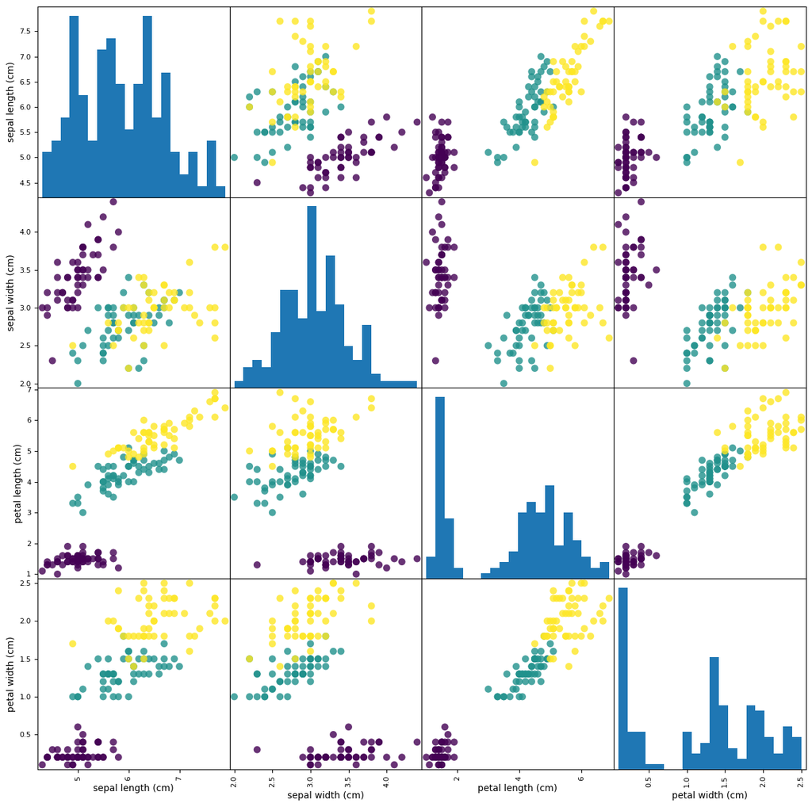

```python
pd.plotting.scatter_matrix(iris, c=y,     # 색
                          figsize=(15,15),         # 크기
                          marker='o',              # 표시
                          hist_kwds={'bins':20},   # 막대의 개수
                          s=60,     # size
                          alpha=0.8 )  # 투명도
```

### 07 첫번째 머신러닝 모델 만들기

- k-최근접 이웃(k-nearest neighbors, k-NN) 알고리즘 :
  - 훈련 데이터에서 새로운 데이터 포인트에 가장 가까운 'k개'의 이웃을 찾는다.
  - 이웃들의 클래스 중 빈도가 가장 높은 클래스를 예측값으로 사용

### 모델 만들기

```python
from sklearn.neighbors import KNeighborsClassifier
model = KNeighborsClassifier(n_neighbors=2)  # 2개의 이웃을 기준
```

### 모델 학습시키기

```python
model.fit(X_train, y_train)
```

```
KNeighborsClassifier(n_neighbors=2)
```

### 하나의 데이터로 예측해 보기

```python
X_new = np.array([[5, 2.9, 1, 0.2]])
```

```python
iris['target']
```

```
0      0
1      0
2      0
3      0
4      0
      ..
145    2
146    2
147    2
148    2
149    2
Name: target, Length: 150, dtype: category
Categories (3, int64): [0, 1, 2]
```

```python
### 예측시키기
pred = model.predict(X_new)
print("예측 : ", pred)
```

```
예측 :  [0]
```

### 08 내가 만든 모델 평가하기

```python
y_pred = model.predict(X_test)
print("예측값 :\n", y_pred)
```

```
예측값 :
 [0 2 1 1 0 1 0 0 2 1 2 2 2 1 0 0 0 1 1 1 0 2 1 1 2 1 1 0 2 0]
```

```python
print("테스트 세트의 정확도 : {:.2f}".format(np.mean(y_pred == y_test)))
```

```
테스트 세트의 정확도 : 0.93
```

### 실습해 보기

- titanic 데이터 셋을 활용하여 knn 모델을 구현해 보자

### REF

- sklearn score 매개변수 : https://scikit-learn.org/stable/modules/model_evaluation.html
- 구글 용어집 : https://developers.google.com/machine-learning/glossary/

### History

- 내용 확인 및 업데이트 2021/10 v11
- 최종 확인 업데이트 2026/01 v13